# Juego_De_La_Vida

## Curso de introducción a la programación con Python

**Autor: Luis Fernando Apáez Álvarez**  
-Curso PyM-  
Clase extra: El juego de la vida  
Fecha: 10 de Septiembre del 2022

Comencemos abordando las siguientes definiciones que ocuparemos a lo largo de esta clase.

- Un sistema dinámico es un sistema cuyo estado evoluciona con el tiempo.
- Un autómata celular es un modelo matemático y computacional para un sistema dinámico que evoluciona en pasos discretos. Este tipo de modelo se utiliza para describir sistemas naturales que pueden ser descritos como una colección masiva de objetos que interactúan entre sí.

Continuemos pues. El **juego de la vida** es un autómata celular diseñado por el matemático John Horton, su estudio es de gran interés y éste presenta diversos comportamientos peculiares. Además muestra como reglas sencillas pueden desencadenar sistemas complejos.

El juego se desarrolla sin jugadores y trata de colocar una serie de fichas (las cuales denominaremos células) en un tablero (el cual representaremos con una matriz) y las dejamos que evolucionen implementando una serie de reglas sencillas. En el juego las células pueden estar vivas o muertas, además una vez muertas pueden revivir, englobado todo al paso del tiempo (discreto).

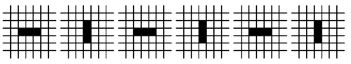

Este tipo de patrones se conocen como *oscilatorios* y en general tenemos los siguientes tipos:

1. **Osciladores:** Son patrones que son predecesores de sí mismos, en otras palabras, son patrones que después de un número finito de pulsos vuelven a su estado inicial.
2. **Vidas estáticas:** Son patrones que no cambian de una generación a la siguiente. El patrón de vidas estáticas es en sí un oscilador de período 1.
3. **Naves espaciales:** Son patrones que aparecen en otra posición tras completar su período.
4. **Matusalenes:** Son patrones que pueden evolucionar tras un número grande de pulsos (o generaciones) antes de estabilizarse.

Comenzaremos por crear una matriz de $10\times 10$ y asignaremos a las entradas el valor de `False`

```python
# dimensiones de la matriz
ﬁlas  =  10
columnas = 10

# Creamos una lista vacía
tablero  =  []

# agregamos el valor de False en todas las entradas
for  i  in  range(ﬁlas):
    tablero.append ([False] * columnas)

# veamos nuestra matriz
for y in range(filas):
    for x in range(columnas):
        print(tablero[y][x], end = " ")
    print()
```

```
False False False False False False False False False False
False False False False False False False False False False
False False False False False False False False False False
False False False False False False False False False False
False False False False False False False False False False
False False False False False False False False False False
False False False False False False False False False False
False False False False False False False False False False
False False False False False False False False False False
False False False False False False False False False False
```

lo cual conseguiremos mediante el código

```python
# asignaremos el valor de True a las siguientes entradas para dibujar el patrón anterior

tablero[4][5] = True
tablero[5][5] = True
tablero[6][5] = True

# implementamos un if para dibujar una célula si el valor de la entrada correspondiente es True
# y en caso contrario que se muestre un punto

for y in range(filas):
    for x in range(columnas):
        if tablero[y][x]:
            print("*", end = " ")
        else:
            print(".", end = " ")
    print()
```

```
. . . . . . . . . .
. . . . . . . . . .
. . . . . . . . . .
. . . . . . . . . .
. . . . . * . . . .
. . . . . * . . . .
. . . . . * . . . .
. . . . . . . . . .
. . . . . . . . . .
. . . . . . . . . .
```

Luego, es preciso aplicar los pulsos para que el patrón cambie, para ello bastará con implementar un bucle for que englobe nuestro tablero

```python
pulsos = 5

for t in range(pulsos):

    # mostramos los pulsos

    print("Pulso: ", t + 1)

    # mostramos el tablero

    for y in range(filas):
        for x in range(columnas):
            if tablero[y][x]:
                print("*", end = " ")
            else:
                print(".", end = " ")
        print()
```

```
Pulso:  1
. . . . . . . . . .
. . . . . . . . . .
. . . . . . . . . .
. . . . . . . . . .
. . . . . * . . . .
. . . . . * . . . .
. . . . . * . . . .
. . . . . . . . . .
. . . . . . . . . .
. . . . . . . . . .
Pulso:  2
. . . . . . . . . .
. . . . . . . . . .
. . . . . . . . . .
. . . . . . . . . .
. . . . . * . . . .
. . . . . * . . . .
. . . . . * . . . .
. . . . . . . . . .
. . . . . . . . . .
. . . . . . . . . .
Pulso:  3
. . . . . . . . . .
. . . . . . . . . .
. . . . . . . . . .
. . . . . . . . . .
. . . . . * . . . .
. . . . . * . . . .
. . . . . * . . . .
. . . . . . . . . .
. . . . . . . . . .
. . . . . . . . . .
Pulso:  4
. . . . . . . . . .
. . . . . . . . . .
. . . . . . . . . .
. . . . . . . . . .
. . . . . * . . . .
. . . . . * . . . .
. . . . . * . . . .
. . . . . . . . . .
. . . . . . . . . .
. . . . . . . . . .
Pulso:  5
. . . . . . . . . .
. . . . . . . . . .
. . . . . . . . . .
. . . . . . . . . .
. . . . . * . . . .
. . . . . * . . . .
. . . . . * . . . .
. . . . . . . . . .
. . . . . . . . . .
. . . . . . . . . .
```

Ahora, nos gustaría que el tablero se actualice pulso por pulso pues el código anterior nos muestra el mismo patrón en todos los pulsos. Lo que buscamos lo conseguiremos implementando las reglas que vimos al inicio. Para ello

```python
pulsos = 5

for t in range(pulsos):

    # mostramos los pulsos

    print("Pulso: ", t + 1)

    for y in range(filas):
        for x in range(columnas):

            # número de vecinos de la celda en cuestión

            n = #....este número lo calcularemos después....

            # Aplicamos las reglas

                # Supervivencia

            if tablero[y][x] and (n == 2 or n ==3):
                tablero[y][x] = True

                # Nacimiento

            elif not tablero[y][x] and n == 3:
                tablero[y][x] = True

                # Superpoblacíon y aislamiento

            else:
                tablero[y][x] = False

    # mostramos el tablero

    for y in range(filas):
        for x in range(columnas):
            if tablero[y][x]:
                print("*", end = " ")
            else:
                print(".", end = " ")
        print()
```

Nuestro código está casi acabado, lo único que falta es determinar el número de vecinos de una célula dada. Para ello consultaremos todas las células vecinas y dado un contador (una variable inicializada en cero) le incrementaremos una unidad por cada célula viva (o equivalentemente cada entrada con valor `True`). Si estamos en la célula `tablero[y][x]` entonces todos sus vecinos son: `tablero[y][x-1]` el de la izquierda, `tablero[y][y+1]` el de la derecha, `tablero[y+1][x]` el de arriba, `tablero[y-1][x]` el de abajo, `tablero[y+1][x-1]` el de arriba a la izquierda, `tablero[y+1][x+1]` el de arriba a la derecha, `tablero[y-1][x-1]` el de abajo a la izquierda y `tablero[y-1][x+1]` el de abajo a la derecha. De tal manera, cada que una de estas células este viva incrementaremos en uno el contador:

```python
# .
# .
# .
    for y in range(filas):
        for x in range(columnas):

            # número de vecinos

            n = 0

            if tablero[y-1][x-1]:
                n += 1
            if tablero[y][x-1]:
                n += 1
            if tablero[y+1][x-1]:
                n += 1
            if tablero[y-1][x]:
                n += 1
            if tablero[y+1][x]:
                n += 1
            if tablero[y-1][x+1]:
                n += 1
            if tablero[y][x+1]:
                n += 1
            if tablero[y+1][x+1]:
                n += 1
# .
# .
# .
```

La idea importante detrás del contador de células vecinas queda plasmado en el código anterior, sin embargo existe un importante error: el índice de la lista queda fuera de rango. Por ejemplo, para el caso en que `x` tenga asignado el valor de 9, tendremos (por ejemplo) que `tablero[y][x+1]` estará evaluado en un índice fuera del rango de la lista pues se tendrá que `x` tendrá asignado el valor de 10. Para solucionar el problema de las células en las fronteras del tablero modificamos el código anterior como

```python
# .
# .
# .
    for y in range(filas):
        for x in range(columnas):

            # número de vecinos

            n = 0

            if y > 0 and x > 0 and tablero[y-1][x-1]:
                n += 1
            if x > 0 and tablero[y][x-1]:
                n += 1
            if y < filas - 1 and x > 0 and tablero[y+1][x-1]:
                n += 1
            if y > 0 and tablero[y-1][x]:
                n += 1
            if y < filas - 1 and tablero[y+1][x]:
                n += 1
            if y > 0 and x < columnas - 1 and tablero[y-1][x+1]:
                n += 1
            if x < columnas - 1 and tablero[y][x+1]:
                n += 1
            if y < filas - 1 and x < columnas - 1 and tablero[y+1][x+1]:
                n += 1
# .
# .
# .
```

Si ejecutamos el código de acuerdo a la construcción que llevamos hasta ahora obtendríamos un tablero (en cada pulso) con puros puntos y ningún asterisco, es decir, todas nuestras células mueren desde el primer pulso. Lo que ocurre es que nuestro tablero se va actualizando durante la propia aplicación de las reglas.

Recordemos que Python ejecuta el código de arriba hacía abajo, de tal manera, cuando nos enfocamos en la célula `tablero[4][5]`, en ese momento, ésta sólo tiene un vecino por lo que muere por regla de aislamiento

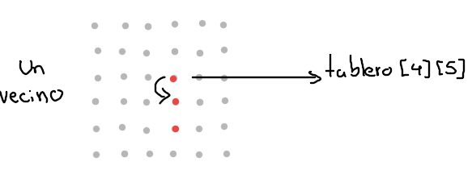

Luego, cuando estemos realizando la ejecución en la siguiente fila, la célula que se supone debía nacer de acuerdo al patrón (`tablero[5][4]`) permanece muerta pues en ese momento sólo tiene dos vecinos; de forma análoga con la célula `tablero[5][6]` que en ese momento tendrá sólo un vecino

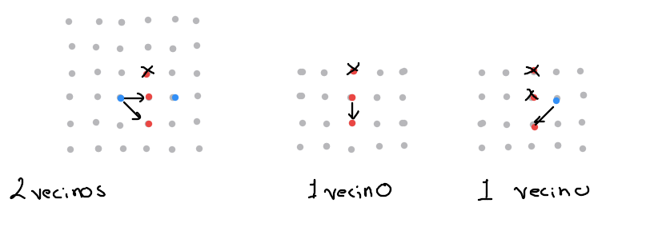

y dado que la célula `tablero[6][5]` es la única sobreviviente, por regla de aislamiento morirá. Es así como nuestro tablero, desde el primer pulso, queda con todas las células muertas y por ende en los consecuentes pulsos permanece así.

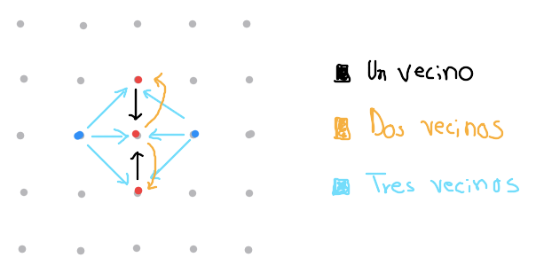

Mientras que los cambios que tendremos en el `tablero2` son

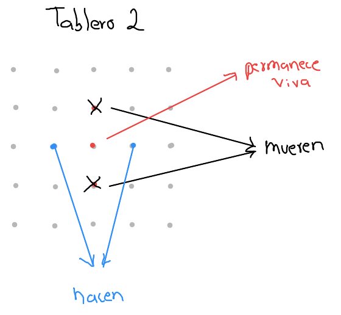

lo cual ya nos arroja el comportamiento que esperabamos. Para conseguir lo anterior en código escribimos

```python
# creamos un nuevo tablero en cada pulso

for t in range(pulsos):

    # Preparamos el tablero nuevo

    tablero2 = []
    for i in range(filas):
        tablero2.append([0] * columnas)

    # mostramos los pulsos
    # .
    # .
    # .
    # código restante
    # .
    # .
    # .

    # aplicamos las reglas en el tablero2

                # Supervivencia

            if tablero[y][x] and (n == 2 or n ==3):
                tablero2[y][x] = True

                # Nacimiento

            elif not tablero[y][x] and n == 3:
                tablero2[y][x] = True

                # Superpoblacíon y aislamiento

            else:
                tablero2[y][x] = False

    # Actualizamos el tablero para traer los cambios al tablero original

    tablero = nuevo
```

Al realizar las anteriores modificaciones a nuestro código original conseguiremos el resultado buscado. Finalmente tenemos el código completo:

```python
# dimensiones de la matriz
ﬁlas  =  10
columnas = 10

# Creamos una lista vacía
tablero  =  []

# agregamos el valor de False en todas las entradas
for  i  in  range(ﬁlas):
    tablero.append ([False] * columnas)

# asignaremos el valor de True a las siguientes entradas para dibujar el patrón anterior (patrón inicial)

tablero[4][5] = True
tablero[5][5] = True
tablero[6][5] = True

# Tablero y pulsos

pulsos = 6

for t in range(pulsos):

    # Preparamos un nuevo tablero

    tablero2 = []
    for i in range(filas):
        tablero2.append([0] * columnas)

    # mostramos los pulsos

    print("Pulso: ", t + 1)

    # Actualizamos el tablero

    for y in range(filas):
        for x in range(columnas):

            # número de vecinos

            n = 0

            if y > 0 and x > 0 and tablero[y-1][x-1]:
                n += 1
            if x > 0 and tablero[y][x-1]:
                n += 1
            if y < filas - 1 and x > 0 and tablero[y+1][x-1]:
                n += 1
            if y > 0 and tablero[y-1][x]:
                n += 1
            if y < filas - 1 and tablero[y+1][x]:
                n += 1
            if y > 0 and x < columnas - 1 and tablero[y-1][x+1]:
                n += 1
            if x < columnas - 1 and tablero[y][x+1]:
                n += 1
            if y < filas - 1 and x < columnas - 1 and tablero[y+1][x+1]:
                n += 1

                # Supervivencia

            if tablero[y][x] and (n == 2 or n ==3):
                tablero2[y][x] = True

                # Nacimiento

            elif not tablero[y][x] and n == 3:
                tablero2[y][x] = True

                # Superpoblacíon y aislamiento

            else:
                tablero2[y][x] = False

    # Actualizamos el tablero

    tablero = tablero2

    # mostramos el tablero

    for y in range(filas):
        for x in range(columnas):
            if tablero[y][x]:
                print("*", end = " ")
            else:
                print(".", end = " ")
        print()
```

```
Pulso:  1
. . . . . . . . . .
. . . . . . . . . .
. . . . . . . . . .
. . . . . . . . . .
. . . . . . . . . .
. . . . * * * . . .
. . . . . . . . . .
. . . . . . . . . .
. . . . . . . . . .
. . . . . . . . . .
Pulso:  2
. . . . . . . . . .
. . . . . . . . . .
. . . . . . . . . .
. . . . . . . . . .
. . . . . * . . . .
. . . . . * . . . .
. . . . . * . . . .
. . . . . . . . . .
. . . . . . . . . .
. . . . . . . . . .
Pulso:  3
. . . . . . . . . .
. . . . . . . . . .
. . . . . . . . . .
. . . . . . . . . .
. . . . . . . . . .
. . . . * * * . . .
. . . . . . . . . .
. . . . . . . . . .
. . . . . . . . . .
. . . . . . . . . .
Pulso:  4
. . . . . . . . . .
. . . . . . . . . .
. . . . . . . . . .
. . . . . . . . . .
. . . . . * . . . .
. . . . . * . . . .
```

[output cut: 11 more lines]

```
. . . . . . . . . .
. . . . . . . . . .
. . . . . . . . . .
. . . . . . . . . .
Pulso:  6
. . . . . . . . . .
. . . . . . . . . .
. . . . . . . . . .
. . . . . . . . . .
. . . . . * . . . .
. . . . . * . . . .
. . . . . * . . . .
. . . . . . . . . .
. . . . . . . . . .
. . . . . . . . . .
```

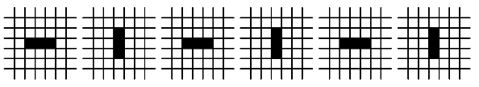